# Atividade Prática 2 — Respostas

Econometria Aplicada à Finanças  
Mestrado Profissional em Administração

Autor

Paulo Aragão Daldegan

Data de Publicação

19 de agosto de 2026

## Questão 1

**a.** O $\hat{\beta}$ ser viesado de $\beta$ significa que ele não está representando o real valor do parâmetro populacional de $\beta$, ou seja, em média o estimador não acerta o valor verdadeiro de $\beta$.

**b.**
$$viés = E(\hat{\beta}) - \beta$$
O viés é a diferença entre o valor esperado do estimador e o verdadeiro parâmetro populacional.

**c.** Porque sempre procuramos representar o verdadeiro parâmetro populacional quando estimamos. Se o estimador estiver viesado, significa que não estamos representando corretamente, subestimando ou superestimando, os valores do verdadeiro parâmetro, podendo levar a conclusões equivocadas.

**d.** Os valores não viesados são os dos estimadores B e C, pois a expectativa da estimativa é igual ao verdadeiro Beta.

**e.** O estimador com a menor variância é o A, mas se trata de um estimador viesado.

**f.** O estimador B se mostrou o melhor, sendo não viesado e com uma variância menor comparado ao estimador C.

**g.** O erro padrão mede a incerteza ou variabilidade dos valores de um estimador entre diferentes amostras, ou seja, irá medir o quanto as estimativas irão variar em torno do verdadeiro parâmetro populacional $\beta$

**h.** Verdadeiro, pois a ausência de viés é uma propriedade definida em termos do valor esperado do estimador para um tamanho de amostra específico, enquanto a consistência é uma propriedade assintótica, relacionada ao comportamento do estimador quando n tende ao infinito.

## Questão 2

**a.**

```r
# Inspecione os dados e calcule as informações solicitadas.
# Inspecionando os dados
glimpse(life_df)
```

```
Rows: 3,106
Columns: 18
$ county_name       <chr> "Autauga", "Autauga", "Baldwin", "Baldwin", "Barbour…
$ county_code       <dbl> 1001, 1001, 1003, 1003, 1005, 1005, 1009, 1009, 1015…
$ state_abb         <chr> "AL", "AL", "AL", "AL", "AL", "AL", "AL", "AL", "AL"…
$ income_quartile   <dbl> 1, 4, 1, 4, 1, 4, 1, 4, 1, 4, 1, 4, 1, 4, 1, 4, 1, 4…
$ life_exp          <dbl> 76.360, 84.215, 79.535, 86.270, 79.733, 86.653, 78.5…
$ pct_uninsured     <dbl> 0.13601, 0.13601, 0.19085, 0.19085, 0.18514, 0.18514…
$ poverty_rate      <dbl> 0.10923, 0.10923, 0.10147, 0.10147, 0.26800, 0.26800…
$ pct_religious     <dbl> 0.56113, 0.56113, 0.47243, 0.47243, 0.41170, 0.41170…
$ pct_black         <dbl> 0.1700900, 0.1700900, 0.1022469, 0.1022469, 0.460396…
$ pct_hispanic      <dbl> 0.0139681, 0.0139681, 0.0175622, 0.0175622, 0.016461…
$ unemployment_rate <dbl> 0.037379, 0.037379, 0.039112, 0.039112, 0.068132, 0.…
$ median_hh_inc     <dbl> 34.380, 34.380, 39.220, 39.220, 24.274, 24.274, 30.2…
$ is_urban          <dbl> 1, 1, 1, 1, 0, 0, 1, 1, 1, 1, 1, 1, 1, 1, 1, 1, 1, 1…
$ pop               <dbl> 43671, 43671, 140415, 140415, 29038, 29038, 51024, 5…
$ pop_density       <dbl> 73.277, 73.277, 87.960, 87.960, 32.815, 32.815, 79.0…
$ pct_smoke         <dbl> 0.333333, 0.133333, 0.268097, 0.176991, 0.228571, 0.…
$ pct_obese         <dbl> 0.37500, 0.13333, 0.29805, 0.13575, 0.29412, 0.27778…
$ pct_exercise      <dbl> 0.50000, 0.80000, 0.59943, 0.83796, 0.54286, 0.72222…
```

```r
# Número de observações
nrow(life_df)
```

```
[1] 3106
```

```r
# Número de Variáveis
ncol(life_df)
```

```
[1] 18
```

```r
# Número de observações completas
sum(complete.cases(life_df))
```

```
[1] 3106
```

```r
# Número de condados distintos
n_distinct(life_df$county_name)
```

```
[1] 1051
```

```r
# Número de estados distintos
n_distinct(life_df$state_abb)
```

```
[1] 50
```

```r
# Número de observações em cada quartil
life_df |>
  count(income_quartile)
```

```
# A tibble: 2 × 2
  income_quartile     n
            <dbl> <int>
1               1  1553
2               4  1553
```

```r
# Valores ausentes em cada variável
sum(colSums(is.na(life_df)))
```

```
[1] 0
```

**b.**

```r
# Crie a variável high_income.
life_df <- life_df |>
  mutate(
    high_income = if_else(income_quartile == 4, 1, 0)
  )
```

**c.**

```r
# Calcule as estatísticas descritivas por quartil de renda.
life_df |>
  group_by(income_quartile) |>
  summarise(
    exp_vida_media = mean(life_exp),
    exp_vida_sd = sd(life_exp),
    taxa_tabagismo_media = mean(pct_smoke),
    taxa_tabagismo_sd = sd(pct_smoke),
    taxa_obesidade_media = mean(pct_obese),
    taxa_obesidade_sd = sd(pct_obese),
    taxa_exercicios_media = mean(pct_exercise),
    taxa_exercicios_sd = sd(pct_exercise)
    )
```

```
# A tibble: 2 × 9
  income_quartile exp_vida_media exp_vida_sd taxa_tabagismo_media
            <dbl>          <dbl>       <dbl>                <dbl>
1               1           78.9        1.45                0.281
2               4           86.0        1.37                0.130
# ℹ 5 more variables: taxa_tabagismo_sd <dbl>, taxa_obesidade_media <dbl>,
#   taxa_obesidade_sd <dbl>, taxa_exercicios_media <dbl>,
#   taxa_exercicios_sd <dbl>
```

Podemos observar que os números são diferentes entre os quartis de renda. O quartil de renda 1 apresentou expectativa de vida média e taxa média de prática de exercícios menor que o quartil 4; por outro lado, apresentou maior taxa média de tabagismo e taxa média de obesidade, demonstrando que há uma diferença perceptível entre os 2 quartis de renda.

**d.**

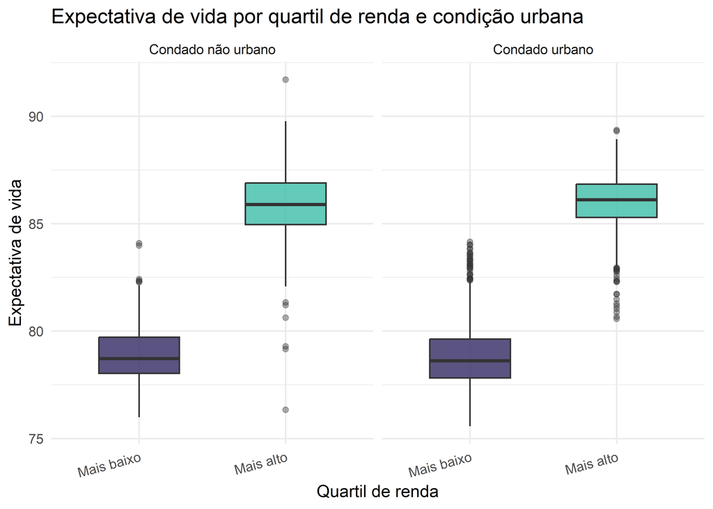

Boxplots da expectativa de vida por grupo de renda e condição urbana.

**e.**

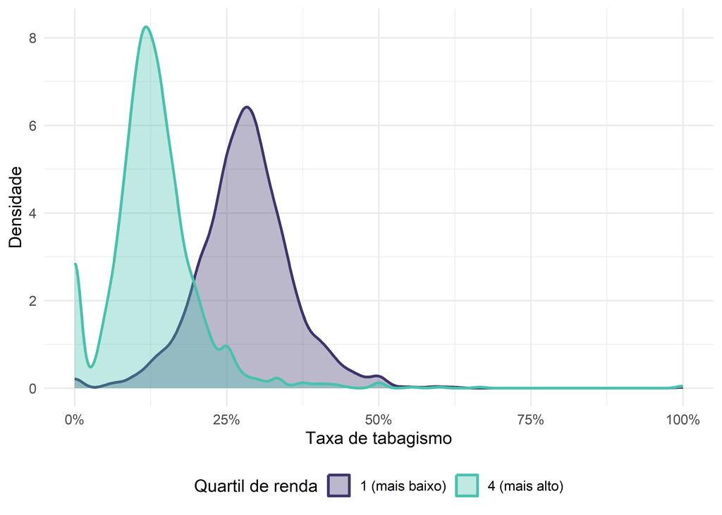

Gráfico de densidade das taxas de tabagismo por grupo de renda.

**f.**

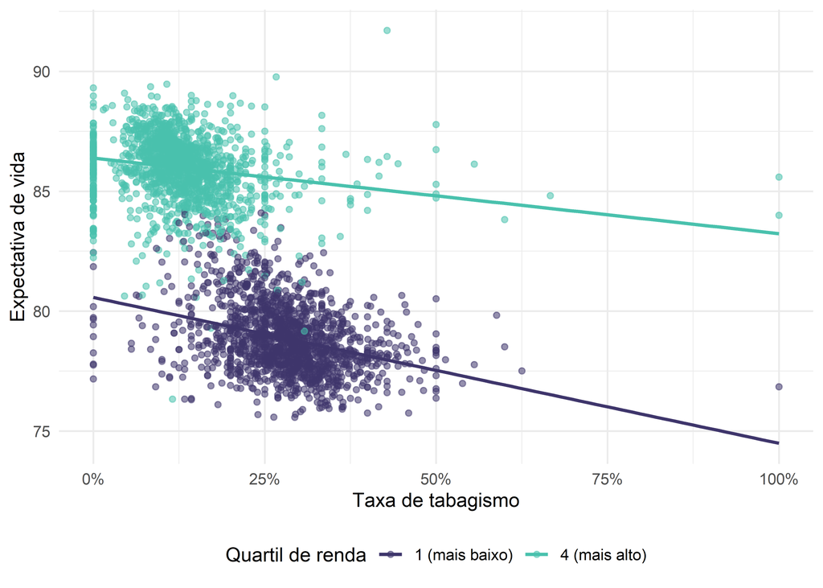

Gráfico de dispersão entre expectativa de vida e taxa de tabagismo.

**g.**

Os gráficos apresentados sugerem que há uma relação da expectativa de vida e da taxa de tabagismo com o quartil de renda em que o indivíduo se encontra. O quartil 1 de renda apresentou resultados piores que o quartil 4 de renda, onde a expectativa de vida é menor, indiferente se o condado é urbano ou não, e a taxa de tabagismo é maior quando comparados. O últiomo gráfico também sugere uma associação entre a expectativa de vida e a taxa de tabagismo, onde uma maior taxa de tabagismo apresenta uma menor expectativa de vida, tanto em um quartil quanto no outro.

**h.**

O gráfico f demonstra que o quartil de renda afeta na expectativa de vida, onde o quartil 1 está associado a uma diminuição e o quartil 4 a um aumento. Além disso, mostra uma relação também com a taxa de tabagismo, sendo o quartil 1 aumentando essa taxa e o quartil 4 diminuindo. Isso demonstra que o quartil de renda é relevante para as 2 variáveis, sendo assim sua ausência pode ocasionar um viés de variável omitida, fazendo com que $E(\hat\beta) \neq \beta$.

**i.**

Espera-se um viés para baixo na estimativa de MQO do coeficiente do tabagismo. Isso ocorre porque o grupo de renda está positivamente relacionado à expectativa de vida, mas negativamente relacionado ao tabagismo.

**j.**

```r
# Estime os modelos simples e com controle para alta renda.
reg_simples <- lm(life_exp ~ pct_smoke, data = life_df)
reg_controle <- lm(life_exp ~ pct_smoke + high_income, data = life_df)

# Organize os resultados em uma tabela.
resultado_1 <- broom::tidy(reg_simples, conf.int = TRUE)
resultado_2 <- broom::tidy(reg_controle, conf.int = TRUE)

resultados <- bind_rows(resultado_1, resultado_2)
knitr::kable(resultados)
```

| term | estimate | std.error | statistic | p.value | conf.low | conf.high |
| --- | --- | --- | --- | --- | --- | --- |
| (Intercept) | 87.5119 | 0.10270 | 852.097 | 0 | 87.3105 | 87.7133 |
| pct_smoke | -24.8084 | 0.44159 | -56.180 | 0 | -25.6742 | -23.9426 |
| (Intercept) | 80.1641 | 0.09311 | 860.963 | 0 | 79.9816 | 80.3467 |
| pct_smoke | -4.6232 | 0.30810 | -15.006 | 0 | -5.2274 | -4.0191 |
| high_income | 6.4106 | 0.06743 | 95.073 | 0 | 6.2784 | 6.5428 |

**k.**

Podemos observar que os valores dos Betas estimados foram diferentes, sendo a previsão feita na questão anterior se confirmando. A inclusão da variável dos quartis de renda diminuiu a intensidade negativa da relação entre tabagismo e expectativa de vida. Na regressão simples, um aumento de 10 pontos percentuais na taxa de tabagismo está associado a uma redução de 2,48 unidades na expectativa de vida. Após controlar por alta renda, esse mesmo aumento está associado a uma redução de apenas 0,46 unidade.

**l.**

```r
# Estime o modelo que também controla para a condição urbana.
reg_controle_condado <- lm(life_exp ~ pct_smoke + high_income + is_urban, data = life_df)
broom::tidy(reg_controle_condado, conf.int = TRUE)
```

```
# A tibble: 4 × 7
  term        estimate std.error statistic  p.value conf.low conf.high
  <chr>          <dbl>     <dbl>     <dbl>    <dbl>    <dbl>     <dbl>
1 (Intercept)  80.1       0.105    762.    0         79.9       80.3
2 pct_smoke    -4.62      0.308    -15.0   3.41e-49  -5.23      -4.02
3 high_income   6.41      0.0674    95.1   0          6.28       6.54
4 is_urban      0.0537    0.0611     0.879 3.79e- 1  -0.0660     0.173
```

A inclusão da variável de condado urbano não alterou significativamente o valor da estimativa do $\beta_1$ associado ao tabagismo. Isso demonstra que o condado ser urbano ou não, não tem relação com a expectativa de vida e com o tabagismo, sendo assim a omissão dessa variável não parece ser uma fonte relevante de viés de variável omitida nesse modelo.